# Lab 3 — dimensionality reduction

#### Group: Q

#### Names:

Luka Secilmis  
Thomas Ecabert  
Aymeric Bacuet  
Berkay Güler

```python
import json
import matplotlib.pyplot as plt
import numpy as np
import pickle

from bokeh.io import show, output_notebook
from bokeh.plotting import figure, ColumnDataSource
from bokeh.models import HoverTool, ResetTool, PanTool, WheelZoomTool, SaveTool
output_notebook()

import sklearn.manifold
from operator import itemgetter

%matplotlib inline
plt.style.use("ggplot")
```

```python
!hdfs dfs -cat /ix/ml-20m/genome-tags.txt | tail -n 2
```

```
WARNING: log4j.properties is not found. HADOOP_CONF_DIR may be incomplete.
{"tagId": 1127, "tag": "zombie"}
{"tagId": 1128, "tag": "zombies"}
```

```python
!hdfs dfs -cat /ix/ml-20m/movies.txt | tail -n 2
```

```
WARNING: log4j.properties is not found. HADOOP_CONF_DIR may be incomplete.
{"genres": ["(no genres listed)"], "movieId": 131260, "title": "Rentun Ruusu (2001)"}
{"genres": ["Adventure", "Fantasy", "Horror"], "movieId": 131262, "title": "Innocence (2014)"}
```

```python
!hdfs dfs -cat /ix/ml-20m/genome-scores.txt | tail -n 2
```

```
WARNING: log4j.properties is not found. HADOOP_CONF_DIR may be incomplete.
{"relevance": 0.11449999999999999, "tagId": 1127, "movieId": 131170}
{"relevance": 0.02174999999999999, "tagId": 1128, "movieId": 131170}
```

- First, necessary txt data is read from hadoop

```python
tag_data = sc.textFile("/ix/ml-20m/genome-tags.txt").map(json.loads)
```

```python
movie_data = sc.textFile("/ix/ml-20m/movies.txt").map(json.loads)
```

```python
score_data = sc.textFile("/ix/ml-20m/genome-scores.txt").map(json.loads)
```

- Here we create python objects using the data in hadoop

```python
movie2name = dict(movie_data.map(itemgetter("movieId", "title")).collect())
```

```python
tag2name = dict(tag_data.map(itemgetter("tagId", "tag")).collect())
```

```python
relevance_data = list(score_data.map(itemgetter("relevance", "tagId", "movieId")).collect())
```

### Exercise 3.1

Some movies has 1128 relevance scores corresponding to each tag, whereas tag information is not given for some movies. Before forming the MxN matrix, we calculate the number of movies with tag information.

```python
relevance_arr = np.array(relevance_data)
```

```python
num_tags = tag_data.count()

# number of movies with tags = total number of movies / # tag entry for each movie
num_tagged_movies = relevance_arr.shape[0] // 1128

print("Number of movies that have a tag:", num_tagged_movies)
print("Number of tags:", num_tags)
```

```
Number of movies that have a tag: 10381
Number of tags: 1128
```

- Hence, the MxN matrix we are asked to construct has dimensions (1128, 10381)
- Since some of the movies do not have tag information, we keep the mapping from column index to movieID in a list to use later on.

```python
def construct_movie_tag_M():
    """
        params:
            None
        return:
            colum_index2movie_ID: list object, contains the movieID for each column in movie_tag_M
            movie_tag_M: np.array, MxN matrix
    """
    column_index2movie_ID = []

    movie_tag_M = np.zeros((num_tags, num_tagged_movies))

    for i in range(num_tagged_movies):
        column_index2movie_ID.append(int(relevance_arr[i*1128, 2]))
        movie_tag_M[:, i] = relevance_arr[i*1128 : (i + 1)*1128, 0]

    return movie_tag_M, column_index2movie_ID
```

```python
movie_tag_M, column_index2movie_ID = construct_movie_tag_M()
```

- Plot the variance of each dimension (represented by tags) across all movies.

```python
movie_tag_VAR = np.var(movie_tag_M, axis=1)
```

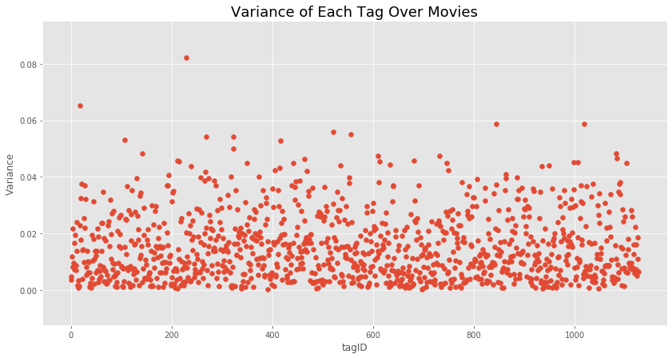

```python
plt.figure(figsize=(14, 7))
plt.scatter(np.arange(0, num_tags), movie_tag_VAR)
plt.title("Variance of Each Tag Over Movies", size=18)
plt.xlabel("tagID")
plt.ylabel("Variance")
```

- Plot the eigenvalues of the M × M covariance matrix.

```python
# (MxM) covariance matrix of movie_tag_M
cov_M = np.cov(movie_tag_M)

# calculate eigenvalues and corresponding eigenvectors, reverse order to have them in ascending order
eigenvalues_cov_M, eigenvectors_cov_M = np.linalg.eigh(cov_M)
eigenvalues = eigenvalues_cov_M[::-1]
eigenvectors = eigenvectors_cov_M[:,::-1]
eigenvalues = list(eigenvalues)
```

```python
# (MxM) covariance matrix has M eigenvalues
num_eigen_vals = len(eigenvalues)
```

- Plot of eigenvalues in descending order

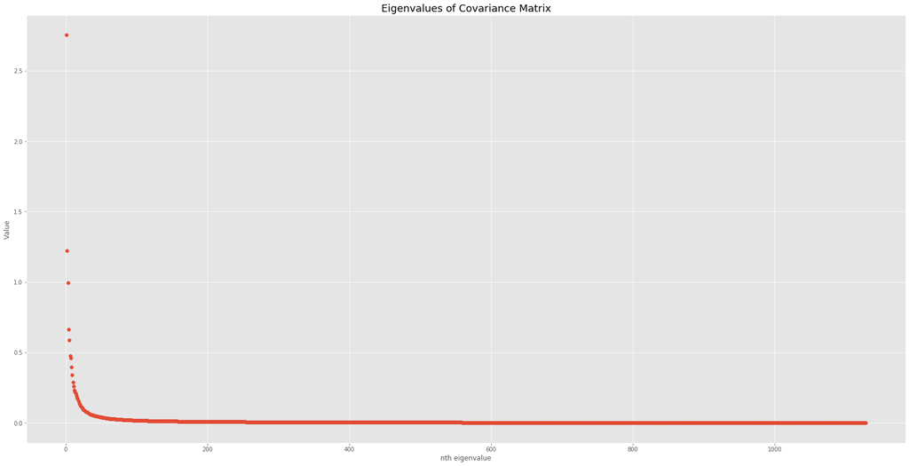

```python
plt.figure(figsize=(28, 14))
plt.scatter(np.arange(1, num_eigen_vals + 1), eigenvalues)
plt.title("Eigenvalues of Covariance Matrix", size=18)
plt.xlabel("nth eigenvalue")
plt.ylabel("Value")
```

#### Discussion

Let's calculate the sum of eigenvalues (variances of cov matrix)

```python
sum_eigen = np.sum(eigenvalues)
print(sum_eigen)
```

```
17.101893239891663
```

To account for the 2/3 of the variability have to choose PCs such that their corresponding eigenvalues sum to 2/3 of 17.1

```python
def find_pcs_var(eigenvalues):
    i = 0
    while (np.sum(eigenvalues[:i]) < sum_eigen * 2/3):
        i += 1

    return i + 1
```

```python
print(find_pcs_var(eigenvalues))
```

```
38
```

Hence, we need to take first ~ 38 PCs to capture 2/3 of the variability in data.

### 3.2 Concept space

- Eigenvectors corresponding to greatest eigenvalues give principal components

```python
# Top five Principal Components
f5_PCAs = eigenvectors[:,:5]
```

```python
# Tags with the 10 highest and lowest coordinates in each PC
tag_ids = np.argsort(f5_PCAs,axis=0)

# we add 1 to each tag beacause tag IDs start from 1
low_10 = tag_ids[:10] + 1
high_10 = tag_ids[-10:][::-1] + 1
```

```python
# PC 1
PC1_low = [tag2name[i] for i in low_10[:,0]]
PC1_high = [tag2name[i] for i in high_10[:,0]]

# PC 2
PC2_low = [tag2name[i] for i in low_10[:,1]]
PC2_high = [tag2name[i] for i in high_10[:,1]]

# PC 3
PC3_low = [tag2name[i] for i in low_10[:,2]]
PC3_high = [tag2name[i] for i in high_10[:,2]]

# PC 4
PC4_low = [tag2name[i] for i in low_10[:,3]]
PC4_high = [tag2name[i] for i in high_10[:,3]]

PC5_low = [tag2name[i] for i in low_10[:,4]]
PC5_high = [tag2name[i] for i in high_10[:,4]]

def pprint(concepts, low_tags, high_tags):

    for i in range(len(concepts)):
        print(f'Concept {i + 1}: {concepts[i]}', end='\n\nLow:\n')
        for j in range(len(low_tags[i])):
            print('\t' + low_tags[i][j])
        print('High:')
        for j in range(len(high_tags[i])):
            print('\t' + high_tags[i][j])
        print('\n-------------------------------------------\n')
```

```python
concepts = ['Quality/Oscar worthiness',
            'Artsy drama films instead of action blockbuster',
            'Love movies instead horror/obscene movies',
            'Science fiction instead of police/crime movies',
            'Crime thriller instead of comedy movies']

low_tags = [PC1_low, PC2_low, PC3_low, PC4_low, PC5_low]
high_tags = [PC1_high, PC2_high, PC3_high, PC4_high, PC5_high]

pprint(concepts, low_tags, high_tags)
```

```
Concept 1: Quality/Oscar worthiness

Low:
	predictable
	so bad it's funny
	bad plot
	silly
	silly fun
	horrible
	franchise
	lame
	big budget
	comedy
High:
	talky
	social commentary
	criterion
	imdb top 250
	great acting
	drama
	oscar (best directing)
	bleak
	dramatic
	cinematography

-------------------------------------------

Concept 2: Artsy drama films instead of action blockbuster

Low:
	action
	special effects
	big budget
	chase
	fast paced
	suspense
	good action
	plot
	pg-13
	action packed
```

[output cut: 79 more lines]

```
	quotable
	funny as hell
High:
	thriller
	conspiracy
	secrets
	suspenseful
	tense
	mystery
	suspense
	investigation
	murder mystery
	betrayal

-------------------------------------------
```

```python
# dict which maps every tag (name) to its coordinates in the 5 first principal directions
tag2coordinates = dict((tag2name[i+1], f5_PCAs[i]) for i in range(1128))
np.save('tag2coordinates.npy', tag2coordinates)
```

### 3.3 Movie Visualization

- First we read the data for selected movies than project them onto first 2 PCs.

```python
# Load selected_movies.pickle
with open("selected-movies.pickle", "rb") as f:
    movies = pickle.load(f, encoding='utf8')

movie_IDs = [movie_info[0] for movie_info in movies]
movie_names = [movie_info[1] for movie_info in movies]
tomato_scores = [movie_info[2] for movie_info in movies]
```

```python
mov_arr = np.zeros((len(movie_IDs), num_tags))

for i in range(len(movie_IDs)):
    # map a movieID to column index in the movie_tag_M
    col_ID = column_index2movie_ID.index(movie_IDs[i])
    # save the tag vector in a row of mov_arr
    # num_tags = 1128
    mov_arr[i, :] = relevance_arr[col_ID * num_tags : (col_ID + 1) * num_tags, 0]
```

```python
projected_pickle = np.matmul(mov_arr, f5_PCAs[:,:2])
```

- Now we have 37 movies with coordinates given in first 2 principal axes.
- Visualize the data as asked in the manual

```python
from matplotlib.colors import rgb2hex

cmap = plt.get_cmap('viridis')

def val2rgb(val):
    return rgb2hex(cmap(val)[:3])

source = ColumnDataSource(
    data={
        # PC 1 coordinate
        "x": projected_pickle[:,0].T,
        # PC 2 coordinate
        "y": projected_pickle[:,1].T,
        "name": movie_names,
        "color": [val2rgb(x) for x in tomato_scores],
        "score": tomato_scores
    })

hover = HoverTool(
    tooltips=[
        ("Name", "@name"), ("RT Score", "@score")
    ])

tools = [hover, ResetTool(), PanTool(), WheelZoomTool(), SaveTool()]

p = figure(plot_width=540, plot_height=540, tools=tools, title="Selected Movies on First 2 Principal Axes")
p.circle("x", "y", source=source, size=20, color="color", alpha=0.5)
show(p, notebook_handle=True)
```

[interactive chart not shown]

`<Bokeh Notebook handle for In[9]>`

#### Discussion

- We discovered previously that first PC (x-axis in plot) embeds Quality/Oscar worthiness as its concept.
- We also discovered that second PC (y-axis in plot) embeds action blockbuster as its concept.
- For example the movie "Star Wars" and "Edge of Tomorrow" are action movies and they are located at the bottom, which means they have the lowest values in second PC while the movies "Take Care of My Cat" and "Wild Strawberries are more emotional and so have higher values in second PC.
- As for the first PC, movies like City of God, Fight Club, American Beauty which are sort of cult/classic movies have great quality so higher values in first PC while "Miss Congenaility" and "Just My Luck" have opposite properties and lower values in first PC.
- We can observe that rotten tomatos score is correlated with both of the PCs.
- Along the first PC (x-axis), we see a increasing rotten tomato score as we get closer to right part of the plot.
- Along the second PC (y-axis), we see a slightly increasing rotten tomato score as we get closer to bottom part of the plot.
- However, the correlation between the second PC and rotten tomato score is weaker.
- This is quite intuitive because as the quality/oscar worthiness of a movie increases its rotten tomato score is expected to increase. On the other hand, a movie's consisting more action vs. being emotional does not neccessarily correlate positively/negatively with its quality/oscar worthiness

# Exercise 3.4

```python
f50_PCAs = eigenvectors[:,:50]
projected_50 = np.matmul(movie_tag_M.T, f50_PCAs)
```

```python
tsne = sklearn.manifold.TSNE(init='pca').fit_transform(projected_50)
```

```python
import random

def sample_tsne(tsne):
    rand_indices = random.sample(range(0, tsne.shape[0]), 1000)
    return tsne[rand_indices,:], list(rand_indices)
```

```python
sampled_tsne, movie_indices = sample_tsne(tsne)
```

```python
# for the sampled movies, find the 5 most relevant tags for each movie

mov_tags_lst = list()

for i in movie_indices:
    relevant_5_tag_IDs = list(np.argsort(movie_tag_M[:,i])[::-1][:5])
    relevant_5_tags = [" " + tag2name[tag_ID+1] for tag_ID in relevant_5_tag_IDs]
    mov_tags_lst.append(relevant_5_tags)
```

```python
# Continuous colors
from matplotlib.colors import rgb2hex
cmap = plt.get_cmap('viridis')
def val2rgb(val):
    return rgb2hex(cmap(val)[:3])

source = ColumnDataSource(
    data={
        "x": sampled_tsne[:,0].T,
        "y": sampled_tsne[:,1].T,
        "name": [movie2name[column_index2movie_ID[ID]] for ID in movie_indices],
        "tags": [tags for tags in mov_tags_lst]})

hover = HoverTool(
    tooltips=[
        ("Name", "@name"), ("Tags", "@tags")
    ])
tools = [hover, ResetTool(), PanTool(), WheelZoomTool(), SaveTool()]

p = figure(plot_width=720, plot_height=720, tools=tools, title="Mouse over the dots")
p.circle("x", "y", source=source, size=20, alpha=0.5)
```

**GlyphRenderer**(

id = '1324', …)

### t-SNE

```python
show(p, notebook_handle=True)
```

[interactive chart not shown]

`<Bokeh Notebook handle for In[46]>`

```python
projected_pca_2D = np.matmul(movie_tag_M.T, f5_PCAs[:,:2])
```

- Here we again use the sampling to make a fair comparison

```python
sampled_pca = projected_pca_2D[movie_indices,:]
```

```python
# Continuous colors
from matplotlib.colors import rgb2hex
cmap = plt.get_cmap('viridis')
def val2rgb(val):
    return rgb2hex(cmap(val)[:3])

source = ColumnDataSource(
    data={
        "x": sampled_pca[:,0].T,
        "y": sampled_pca[:,1].T,
        "name": [movie2name[column_index2movie_ID[ID]] for ID in movie_indices],
        "tags": [tags for tags in mov_tags_lst]})

hover = HoverTool(
    tooltips=[
        ("Name", "@name"), ("Tags", "@tags")
    ])
tools = [hover, ResetTool(), PanTool(), WheelZoomTool(), SaveTool()]

p = figure(plot_width=720, plot_height=720, tools=tools, title="Mouse over the dots")
p.circle("x", "y", source=source, size=20, alpha=0.5)
```

**GlyphRenderer**(

id = '1435', …)

### PCA

```python
show(p, notebook_handle=True)
```

[interactive chart not shown]

`<Bokeh Notebook handle for In[48]>`

### Discussion

We observe that the t-SNE plot is much more centered and uniformly distributed than the PCA plot. Furthemore the tags and their corresponding concepts are much better grouped together.  
If we hover over the part of our PCA plot which is the most dense (around coordinate (2,-2)) we see that the concepts/genres are much more mixed. For instance we find horror right next to romantic comedy, while for the t-SNE plot the tags of the neighbours of a point are always much more coherent with those of the point - for instance around a coordinate with horror tag we will find more horror movies rather than a romantic comedy.  
Thus the clusters of the t-SNE plot are much more interpretable.

This happens because t-SNE is able to preserve the structure of the high dimensional data better than PCA - points which are close to each other in the high-dimensional data will tend to be close to each other in the reduced dimension. This is because, as seen in the course, the t-SNE algorithm will try to preserve nearest-neighbor relationships as much as possible.